# Predicting whether customers will succesfully repay the loans or No: Using Decision Tree and Random Forest Model

Executed by Neha More

Nov 3rd, 2017

**PROBLEM STATEMENT**

Payday Loans are high risk short term lending financial products and its very important to asses risk of payment default. Use dataset “paydayloan_collections.csv” to build a model whether repayment will be successful or not.

**AIM: Break the dataset into test and train data.Use RandomForest and DecisionTress to build your model on train data and compare their performance on test data.**

Initial Setup for using decision tree and random forest model:

```r
library(tree)
library(ISLR)
library(randomForest)
library(dplyr)
loan=read.csv("paydayloan_collections.csv")
View(loan)
str(loan) #VERY IMP TO NOTE THAT PAYMENT IS OF FACTOR TYPE...WHILE REST OTHERS ARE ALSO OF FACTOR N NUM TYPE.
```

```
## 'data.frame':    30000 obs. of  31 variables:
##  $ payment: Factor w/ 2 levels "Denied","Success": 2 1 1 2 2 2 2 2 1 1 ...
##  $ var1   : Factor w/ 4 levels "kq","ma","qw",..: 3 3 3 4 2 1 4 3 4 3 ...
##  $ var2   : Factor w/ 9 levels "bq","hk","js",..: 2 7 9 3 8 5 5 7 7 7 ...
##  $ var3   : num  3.11 3.35 4.15 6.23 1.28 -2.45 1.05 5.41 7.29 3.13 ...
##  $ var4   : num  16.1 11.2 29.2 15.7 20.7 ...
##  $ var5   : num  -4.6 -18.55 18.91 2.81 14.98 ...
##  $ var6   : num  22.34 6.68 16.4 4.46 11.19 ...
##  $ var7   : num  13.53 12.78 3.67 5.13 17.66 ...
##  $ var8   : num  1.53 6.62 5.72 8.66 1.13 ...
##  $ var9   : Factor w/ 3 levels "ch","ja","nv": 3 3 1 2 3 1 1 1 1 1 ...
##  $ var10  : Factor w/ 3 levels "db","ld","pe": 2 2 2 2 2 1 2 2 1 2 ...
##  $ var11  : Factor w/ 2 levels "rl","te": 1 2 2 2 2 2 2 2 2 1 ...
##  $ var12  : num  4.46 4.04 -4.41 2.14 14.93 ...
##  $ var13  : Factor w/ 7 levels "cb","iz","kh",..: 1 3 1 2 6 2 1 1 3 6 ...
```

[output cut: 17 more lines]

```r
glimpse(loan)
```

```
## Observations: 30,000
## Variables: 31
## $ payment <fctr> Success, Denied, Denied, Success, Success, Success, S...
## $ var1    <fctr> qw, qw, qw, wv, ma, kq, wv, qw, wv, qw, qw, qw, wv, w...
## $ var2    <fctr> hk, rv, zg, js, xn, py, py, rv, rv, rv, py, bq, py, p...
## $ var3    <dbl> 3.11, 3.35, 4.15, 6.23, 1.28, -2.45, 1.05, 5.41, 7.29,...
## $ var4    <dbl> 16.06, 11.18, 29.19, 15.70, 20.71, 22.45, 23.02, 17.92...
## $ var5    <dbl> -4.60, -18.55, 18.91, 2.81, 14.98, 15.18, 17.59, -14.5...
## $ var6    <dbl> 22.34, 6.68, 16.40, 4.46, 11.19, -2.12, 6.65, 5.00, 13...
## $ var7    <dbl> 13.53, 12.78, 3.67, 5.13, 17.66, -8.24, -2.06, 1.34, 2...
## $ var8    <dbl> 1.53, 6.62, 5.72, 8.66, 1.13, 10.34, 12.20, -8.54, 4.4...
## $ var9    <fctr> nv, nv, ch, ja, nv, ch, ch, ch, ch, ch, ch, ch, ch, n...
## $ var10   <fctr> ld, ld, ld, ld, ld, db, ld, ld, db, ld, ld, ld, db, l...
## $ var11   <fctr> rl, te, te, te, te, te, te, te, te, rl, te, rl, te, t...
## $ var12   <dbl> 4.46, 4.04, -4.41, 2.14, 14.93, 8.64, 14.91, 13.97, 15...
```

[output cut: 18 more lines]

```r
table(loan$payment)
```

```
##
##  Denied Success
##   18755   11245
```

the reponse variable is of classification type.ie.payment=denied/sucess lets make decision tree first and then random forest method

**Step 1:divide the data into train and test(50:50%)**

```r
set.seed(2)
s=sample(1:nrow(loan),15000)
loan_train=loan[s,]
loan_test=loan[-s,]
```

**step 2: making tree model for train data**

```r
tree.loan=tree(payment~.,data=loan_train)
```

lets plot it

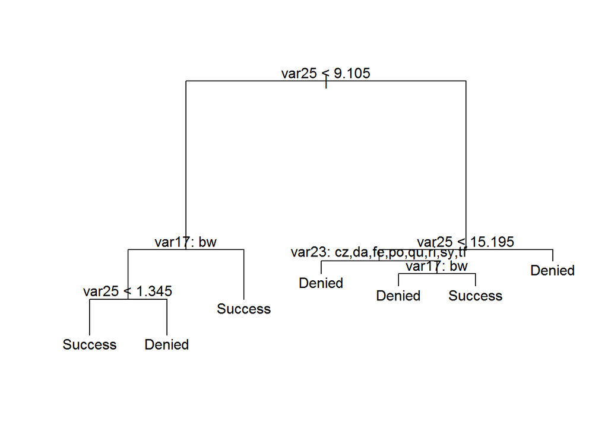

```r
plot(tree.loan) #model with 7 nodes.
text(tree.loan,pretty=0)
```

```r
tree.loan #text format output
```

```
## node), split, n, deviance, yval, (yprob)
##       * denotes terminal node
##
##  1) root 15000 19790.0 Denied ( 0.62847 0.37153 )
##    2) var25 < 9.105 7041  9332.0 Success ( 0.37722 0.62278 )
##      4) var17: bw 3197  4338.0 Denied ( 0.58555 0.41445 )
##        8) var25 < 1.345 1355  1661.0 Success ( 0.30258 0.69742 ) *
##        9) var25 > 1.345 1842  1875.0 Denied ( 0.79370 0.20630 ) *
##      5) var17: az,ki,ov,zk 3844  3889.0 Success ( 0.20395 0.79605 ) *
##    3) var25 > 9.105 7959  6708.0 Denied ( 0.85074 0.14926 )
##      6) var25 < 15.195 3510  3703.0 Denied ( 0.77949 0.22051 )
##       12) var23: cz,da,fe,po,qu,ri,sy,tf 2778  2408.0 Denied ( 0.84377 0.15623 ) *
##       13) var23: ub,yv 732  1011.0 Denied ( 0.53552 0.46448 )
##         26) var17: bw 327   262.0 Denied ( 0.86239 0.13761 ) *
##         27) var17: az,ki,ov,zk 405   473.7 Success ( 0.27160 0.72840 ) *
##      7) var25 > 15.195 4449  2754.0 Denied ( 0.90695 0.09305 ) *
```

```r
summary(tree.loan)
```

```
##
## Classification tree:
## tree(formula = payment ~ ., data = loan_train)
## Variables actually used in tree construction:
## [1] "var25" "var17" "var23"
## Number of terminal nodes:  7
## Residual mean deviance:  0.8886 = 13320 / 14990
## Misclassification error rate: 0.1718 = 2577 / 15000
```

output:for train dataset having 7 nodes: residual mean dev=0.88 error rate=0.1718

**step 3:predict for test dataset**

```r
tree.pred=predict(tree.loan,newdata = loan_test,type ="class")
```

**step 4:check the predictions made on test data and calculate error.**

```r
table(tree.pred,loan_test$payment)
```

```
##
## tree.pred Denied Success
##   Denied    8076    1373
##   Success   1252    4299
```

```r
(1252+1373)/15000
```

```
## [1] 0.175
```

error on test data=0.175

lets find error on train data:

```r
tree.pred.train=predict(tree.loan,newdata = loan_train,type ="class")
table(tree.pred.train,loan_train$payment)
```

```
##
## tree.pred.train Denied Success
##         Denied    8123    1273
##         Success   1304    4300
```

```r
(1304+1273)/15000
```

```
## [1] 0.1718
```

**CONCLUSION:ERROR FOUND ON TRAIN DATA IS 0.1718 WHILE ON TEST DATA 0.175.(GOOD MODEL)**

**Step 5: STILL LETS TRY AND DO PRUNING FOR OPTIMUM MODEL OF TREE.** **WE HERE USE CROSS VALIDATION FUNCTION AND PRUNE FUNCTION**

`r set.seed(2) cv.loan=cv.tree(tree.loan,FUN = prune.misclass)`

lets plot the pruned tree

`r plot(cv.loan$size,cv.loan$dev,type="b")`

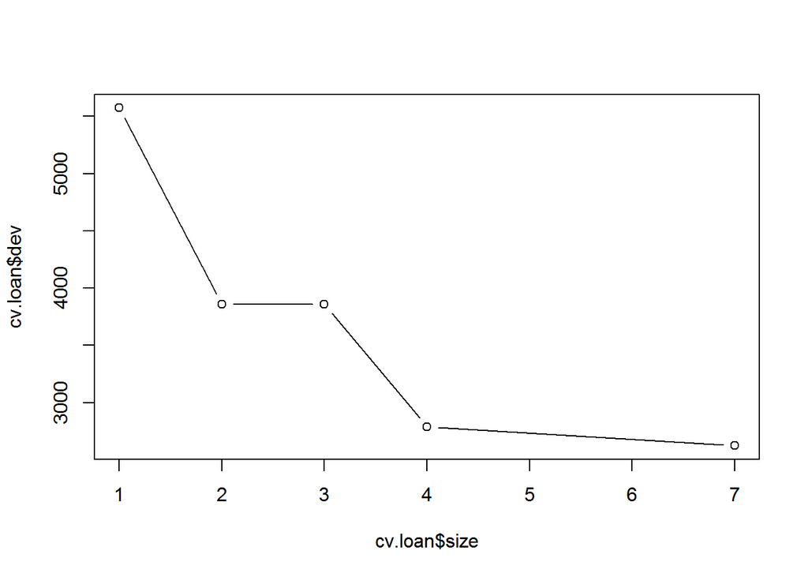

plot shows that error is minimum on 7 nodes ONLY where deviance is minimum

**Hence the tree itself is best size with 7 nodes which already exist.**

**Lets do random forest method**

*Here response is clasification type(payment=success/denied)*

**step 1:build rf model on train dataset.**

```r
rf.loan=randomForest(payment~.,data = loan_train)#U CAN USE ARGUMENT do.trace=T
rf.loan
```

```
##
## Call:
##  randomForest(formula = payment ~ ., data = loan_train)
##                Type of random forest: classification
##                      Number of trees: 500
## No. of variables tried at each split: 5
##
##         OOB estimate of  error rate: 13.43%
## Confusion matrix:
##         Denied Success class.error
## Denied    8537     890  0.09440967
## Success   1125    4448  0.20186614
```

*output: interpretatn:ntree=500 no. of variables tried at each split=5 OOB estimate of error rate=13.43% i.e.(1125+890)/15000=13.43%*

**step 2:predicting rf model created on test dataset and find error**

```r
rf.loan.pred=predict(rf.loan,newdata = loan_test)
t=table(loan_test$payment,rf.loan.pred)
t
```

```
##          rf.loan.pred
##           Denied Success
##   Denied    8496     832
##   Success   1149    4523
```

interpretation:

```r
(1149+832)/15000
```

```
## [1] 0.1320667
```

error=13.20% by random forest model.

**step 3:Plot variablesImpPlot(i.e. variableswhich are important):**

```r
importance(rf.loan)
```

```
##       MeanDecreaseGini
## var1          40.32600
## var2         128.59517
## var3         168.25258
## var4         167.97693
## var5         163.46701
## var6         163.03284
## var7         252.18814
## var8         165.88244
## var9          25.67926
## var10         26.78148
## var11         12.40307
## var12        160.85998
## var13         98.65424
## var14        164.22960
## var15        168.69391
## var16        340.11406
## var17        517.84024
## var18        167.12299
## var19         96.80594
## var20        162.52858
## var21        168.95544
## var22        168.19927
## var23        265.28208
## var24        168.26335
## var25       2360.36785
## var26        157.98775
## var27        162.64079
## var28        154.84962
## var29         39.65420
## var30        167.07499
```

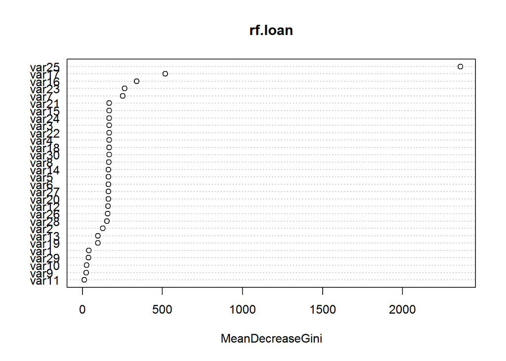

```r
varImpPlot(rf.loan)
```

variables 25,17,16,23 are most imp variables contributing to the output.

**Conclusion:error generated on PREDICTING TEST data by random forest is 13.20% as against 17.5% by decision tree model.**

**Hence random forest is better than decision tree model .**